# Introduction to Spectra object

Mohieddin Jafari

2026-05-01 11:48:34

### Quiz 1 (IA_4)

Visit `gosocrative.com` and enter room name `FIN2026`

## Library

```r
# if (!require("BiocManager", quietly = TRUE))
#     install.packages("BiocManager")
#
# BiocManager::install("PSMatch")
# if (!requireNamespace("remotes", quietly = TRUE))
#     install.packages("remotes")
#
# remotes::install_github("RforMassSpectrometry/SpectraVis")

# library(rpx)
# library(msdata)
# library(rpx)
# library(Spectra)
# library(tidyverse)
# library(cleaver)
# library(MSnbase)
# library(SpectraVis)
# library(mzR)
# library(PSMatch)
```

# Toy spectra

```r
library(S4Vectors)
library(Spectra)
## Let’s create a DataFrame containing MS levels, retention time, m/z and intensities for 2 spectra

## data.frame
## tibble
(spd <- DataFrame(msLevel = c(1L, 2L), #S4-based extension of data.frame from Bioconductor, designed for genomic and biological data with support for complex metadata and attributes.
          rtime = c(1.1, 1.2)))
```

```
## DataFrame with 2 rows and 2 columns
##     msLevel     rtime
##   <integer> <numeric>
## 1         1       1.1
## 2         2       1.2
```

```r
spd$mz <- list(
  c(100, 103.2, 132, 210),
  c(45, 100, 200)
)

spd$intensity <- list(
  c(45, 12, 345, 20),
  c(45, 122, 12)
)

# Convert this generic object to format of Spectra object
(sp <- Spectra(spd))
```

```
## MSn data (Spectra) with 2 spectra in a MsBackendMemory backend:
##     msLevel     rtime scanIndex
##   <integer> <numeric> <integer>
## 1         1       1.1        NA
## 2         2       1.2        NA
##  ... 16 more variables/columns.
```

## Create the Spectra object from f

```r
library(rpx)
f <- pxget(PXDataset("PXD000001"),
           "TMT_Erwinia_1uLSike_Top10HCD_isol2_45stepped_60min_01-20141210.mzML")
```

```
## Loading PXD000001 from cache.
```

```
## Loading TMT_Erwinia_1uLSike_Top10HCD_isol2_45stepped_60min_01-20141210.mzML from cache.
```

```r
(sp <- Spectra(f)) # It retrieves from Hard not memory when it is not manually created spectra (MsBackendMzR), so it takes a little bit of time to retrieve.
```

```
## MSn data (Spectra) with 7534 spectra in a MsBackendMzR backend:
##        msLevel     rtime scanIndex
##      <integer> <numeric> <integer>
## 1            1    0.4584         1
## 2            1    0.9725         2
## 3            1    1.8524         3
## 4            1    2.7424         4
## 5            1    3.6124         5
## ...        ...       ...       ...
## 7530         2   3600.47      7530
## 7531         2   3600.83      7531
## 7532         2   3601.18      7532
## 7533         2   3601.57      7533
## 7534         2   3601.98      7534
##  ... 34 more variables/columns.
##
## file(s):
## 100d1647358d7_TMT_Erwinia_1uLSike_Top10HCD_isol2_45stepped_60min_01-20141210.mzML
```

```r
print(object.size(sp), units = "Mb") # Small and not overload memory
```

```
## 2.8 Mb
```

```r
length(sp)
```

```
## [1] 7534
```

```r
spectraVariables(sp)
```

```
##  [1] "msLevel"                  "rtime"
##  [3] "acquisitionNum"           "scanIndex"
##  [5] "dataStorage"              "dataOrigin"
##  [7] "centroided"               "smoothed"
##  [9] "polarity"                 "precScanNum"
## [11] "precursorMz"              "precursorIntensity"
## [13] "precursorCharge"          "collisionEnergy"
## [15] "isolationWindowLowerMz"   "isolationWindowTargetMz"
## [17] "isolationWindowUpperMz"   "peaksCount"
## [19] "totIonCurrent"            "basePeakMZ"
## [21] "basePeakIntensity"        "electronBeamEnergy"
## [23] "ionisationEnergy"         "lowMZ"
## [25] "highMZ"                   "mergedScan"
## [27] "mergedResultScanNum"      "mergedResultStartScanNum"
## [29] "mergedResultEndScanNum"   "injectionTime"
## [31] "filterString"             "spectrumId"
## [33] "ionMobilityDriftTime"     "scanWindowLowerLimit"
## [35] "scanWindowUpperLimit"
```

```r
pd <- peaksData(sp)
dim(pd[[1345]])
```

```
## [1] 193   2
```

```r
head(pd[[1345]])
```

```
##            mz intensity
## [1,] 110.0709 26983.111
## [2,] 112.0871  3120.129
## [3,] 112.1121  4877.857
## [4,] 113.1149  3201.889
## [5,] 114.1190  3963.569
## [6,] 116.0694  3245.372
```

```r
?Spectra
## ---- ACCESSING AND ADDING DATA ----
```

| Category | Field | Description |
| --- | --- | --- |
| Basic Info | msLevel | MS level of the scan (e.g., MS1 = full scan, MS2 = fragmentation scan). Example: MS2 is used for peptide identification. |
|  | rtime | Retention time (in seconds) when the spectrum was recorded during LC separation. Example: 320.5 sec = ~5.3 min into run. |
|  | acquisitionNum | Sequential scan acquisition number assigned by the instrument. |
|  | scanIndex | Index position of the spectrum in the dataset. |
|  | spectrumId | Unique spectrum identifier string. |
|  | dataOrigin | Original raw file or dataset source. |
| Signal Processing | centroided | Whether peak detection is centroided (TRUE = peaks simplified to single m/z-intensity pairs). |
|  | smoothed | Whether signal smoothing was applied before peak detection. |
|  | polarity | Ion polarity used in MS (positive or negative mode). |
| Precursor (MS/MS) | precursorMz | m/z of selected precursor ion for MS/MS fragmentation. Example: 523.2 m/z peptide ion. |
|  | precursorIntensity | Intensity of precursor ion before fragmentation (signal strength). |
|  | precursorCharge | Charge state of precursor ion (e.g., +2, +3 typical for peptides). |
|  | precScanNum | Scan number where precursor ion was detected. |
|  | collisionEnergy | Collision energy used to fragment precursor ions (higher = stronger fragmentation). |
| Isolation Window | isolationWindowLowerMz | Lower boundary of m/z window used to isolate precursor ion. |
|  | isolationWindowTargetMz | Target m/z selected for isolation and fragmentation. |
|  | isolationWindowUpperMz | Upper boundary of isolation window. |
| Spectrum Statistics | peaksCount | Number of detected peaks in the spectrum. |
|  | totIonCurrent | Total ion current (sum of all intensities in the scan). |
|  | basePeakMZ | m/z value of the most intense peak in the spectrum. |
|  | basePeakIntensity | Intensity of the base peak (strongest signal). |
| m/z Range | lowMZ | Lowest m/z value recorded in the scan (instrument range start). |
|  | highMZ | Highest m/z value recorded in the scan (instrument range end). |
| Acquisition Details | injectionTime | Ion injection time (how long ions were accumulated before scan). |
|  | filterString | Instrument filter string describing scan settings (e.g., MS2 selection rules). |
| Merging Info | mergedScan | Whether multiple scans were merged into one spectrum. |
|  | mergedResultScanNum | Scan number of merged result. |
|  | mergedResultStartScanNum | Starting scan number used in merging. |
|  | mergedResultEndScanNum | Ending scan number used in merging. |
| Advanced | ionMobilityDriftTime | Ion mobility drift time (separation dimension in IMS experiments). |
|  | scanWindowLowerLimit | Lower m/z limit of scan window. |
|  | scanWindowUpperLimit | Upper m/z limit of scan window. |
|  | electronBeamEnergy | Electron beam energy used in fragmentation (instrument-specific). |

```r
#Two ways for a purpose
head(msLevel(sp), 250)
```

```
##   [1] 1 1 1 1 1 1 1 1 1 1 1 1 1 1 1 1 1 1 1 1 1 1 1 1 1 1 1 1 1 1 1 1 1 1 1 1 1
##  [38] 1 1 1 1 1 1 1 1 1 1 1 1 1 1 1 1 1 1 1 1 1 1 1 1 1 1 1 1 1 1 1 1 1 1 1 1 1
##  [75] 1 1 1 1 1 1 1 1 1 1 1 1 1 1 1 1 1 1 1 1 1 1 1 1 1 1 1 1 1 1 1 1 1 1 1 1 1
## [112] 1 1 1 1 1 1 1 1 1 1 1 1 1 1 1 1 1 1 1 1 1 1 1 1 1 1 1 1 1 1 1 1 1 1 1 1 1
## [149] 1 1 1 1 1 1 1 1 1 1 1 1 1 1 1 1 1 1 1 1 1 1 1 1 1 1 1 1 1 1 1 1 1 1 1 1 1
## [186] 1 1 1 1 1 1 1 1 1 1 1 1 1 1 1 1 1 1 1 1 1 1 1 1 1 1 1 1 1 1 1 1 1 1 1 1 1
## [223] 1 1 1 1 2 2 2 2 2 2 2 2 2 2 1 2 2 1 2 2 2 2 2 2 1 1 1 1
```

```r
#head(sp$msLevel, 250)

msLevel(sp)[[1234]]
```

```
## [1] 2
```

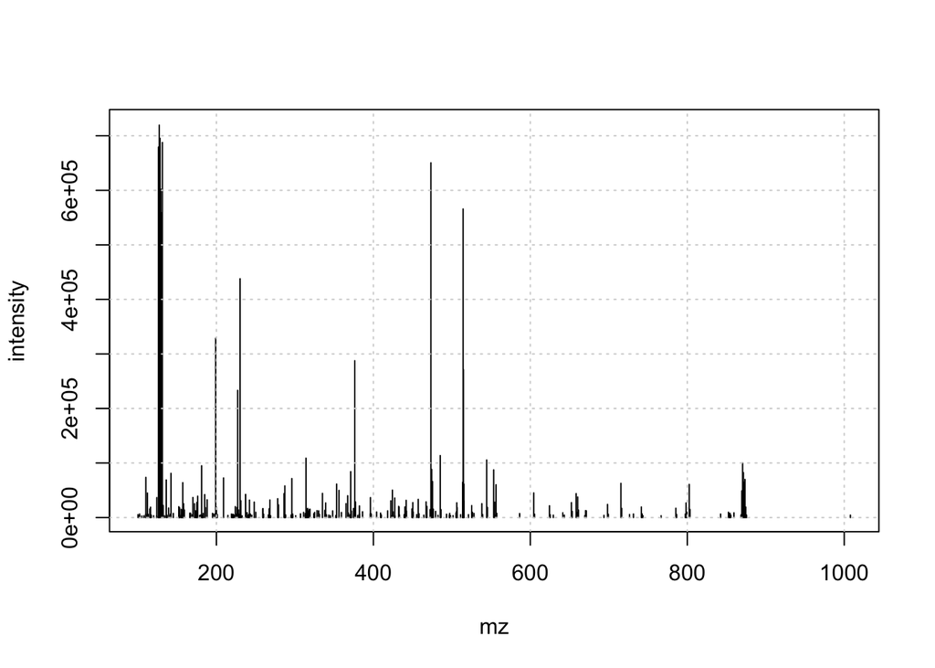

```r
plot(pd[[1234]], type = "h"); grid()
```

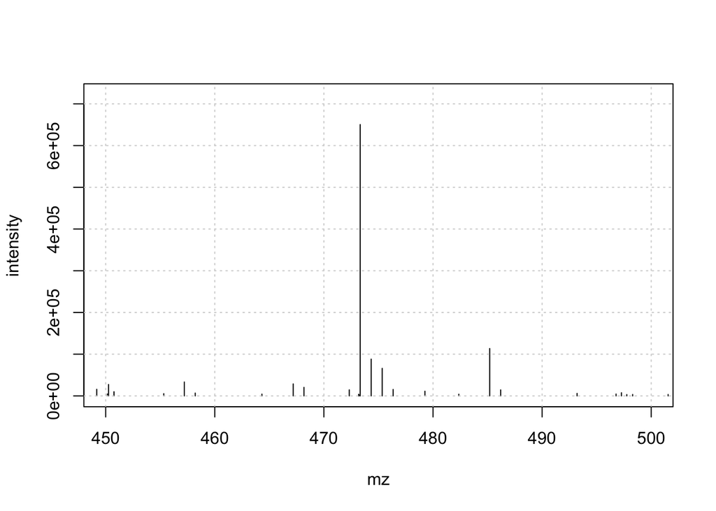

```r
plot(pd[[1234]], type = "h", xlim = c(450, 500)); grid()
```

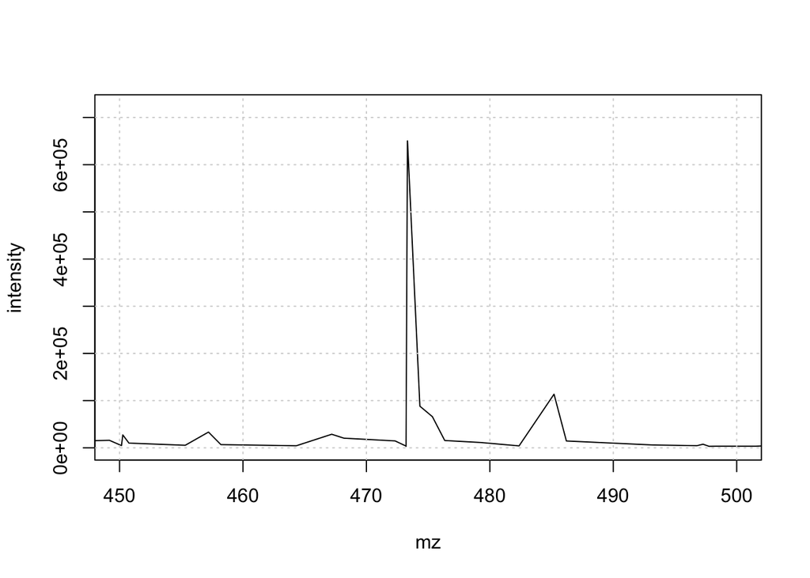

```r
plot(pd[[1234]], type = "l", xlim = c(450, 500)); grid()
```

```r
head(pd[[1234]])
```

```
##            mz intensity
## [1,] 100.1033  5289.453
## [2,] 101.7289  3195.333
## [3,] 102.0549  6471.115
## [4,] 102.6006  2791.225
## [5,] 105.0795  2869.442
## [6,] 107.7553  3242.816
```

```r
sp$intensity[[1234]] |> summary()
```

```
##    Min. 1st Qu.  Median    Mean 3rd Qu.    Max.
##    2645    5279   10404   41216   26840  719455
```

```r
sp$lowMZ[1234]
```

```
## [1] 100.1033
```

```r
sp$highMZ[1234]
```

```
## [1] 1007.864
```

```r
head(precursorMz(sp), 500)
```

```
##   [1]       NA       NA       NA       NA       NA       NA       NA       NA
##   [9]       NA       NA       NA       NA       NA       NA       NA       NA
##  [17]       NA       NA       NA       NA       NA       NA       NA       NA
##  [25]       NA       NA       NA       NA       NA       NA       NA       NA
##  [33]       NA       NA       NA       NA       NA       NA       NA       NA
##  [41]       NA       NA       NA       NA       NA       NA       NA       NA
##  [49]       NA       NA       NA       NA       NA       NA       NA       NA
##  [57]       NA       NA       NA       NA       NA       NA       NA       NA
##  [65]       NA       NA       NA       NA       NA       NA       NA       NA
##  [73]       NA       NA       NA       NA       NA       NA       NA       NA
##  [81]       NA       NA       NA       NA       NA       NA       NA       NA
##  [89]       NA       NA       NA       NA       NA       NA       NA       NA
##  [97]       NA       NA       NA       NA       NA       NA       NA       NA
## [105]       NA       NA       NA       NA       NA       NA       NA       NA
## [113]       NA       NA       NA       NA       NA       NA       NA       NA
```

[output cut: 48 more lines]

```r
precursorMz(sp)[1234]
```

```
## [1] 514.7814
```

```r
#How many MS levels are there, and how many scans of each level?
table(msLevel(sp))
```

```
##
##    1    2
## 1431 6103
```

```r
#filter family functions
(sp2 <- filterMsLevel(sp, 2L))
```

```
## MSn data (Spectra) with 6103 spectra in a MsBackendMzR backend:
##        msLevel     rtime scanIndex
##      <integer> <numeric> <integer>
## 1            2   202.354       227
## 2            2   203.069       228
## 3            2   203.491       229
## 4            2   203.960       230
## 5            2   204.492       231
## ...        ...       ...       ...
## 6099         2   3600.47      7530
## 6100         2   3600.83      7531
## 6101         2   3601.18      7532
## 6102         2   3601.57      7533
## 6103         2   3601.98      7534
##  ... 34 more variables/columns.
##
## file(s):
## 100d1647358d7_TMT_Erwinia_1uLSike_Top10HCD_isol2_45stepped_60min_01-20141210.mzML
## Processing:
##  Filter: select MS level(s) 2 [Fri May  1 11:48:44 2026]
```

```r
#sp[msLevel(sp) == 2L]

max(sp$basePeakIntensity)
```

```
## [1] 1748258688
```

```r
rtime(sp)[1234]
```

```
## [1] 1220.774
```

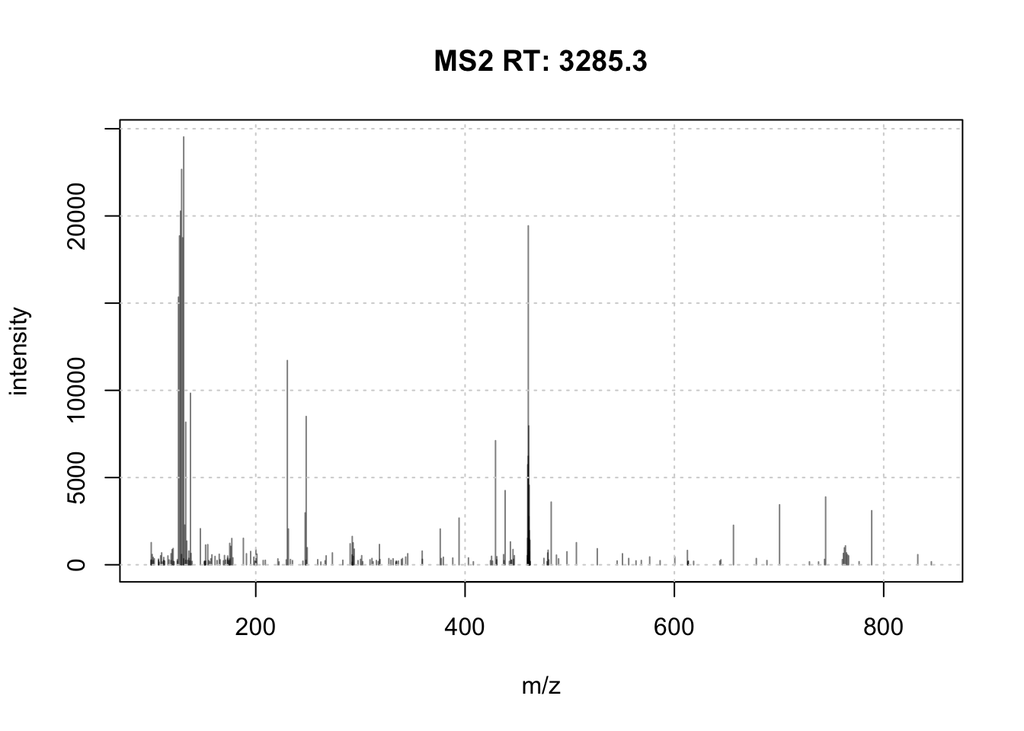

```r
plotSpectra(sp2[5404]); grid()
```

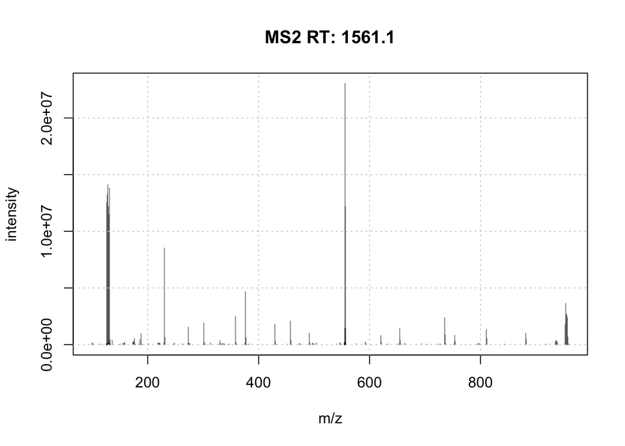

```r
plotSpectra(sp2[1234]); grid()
```

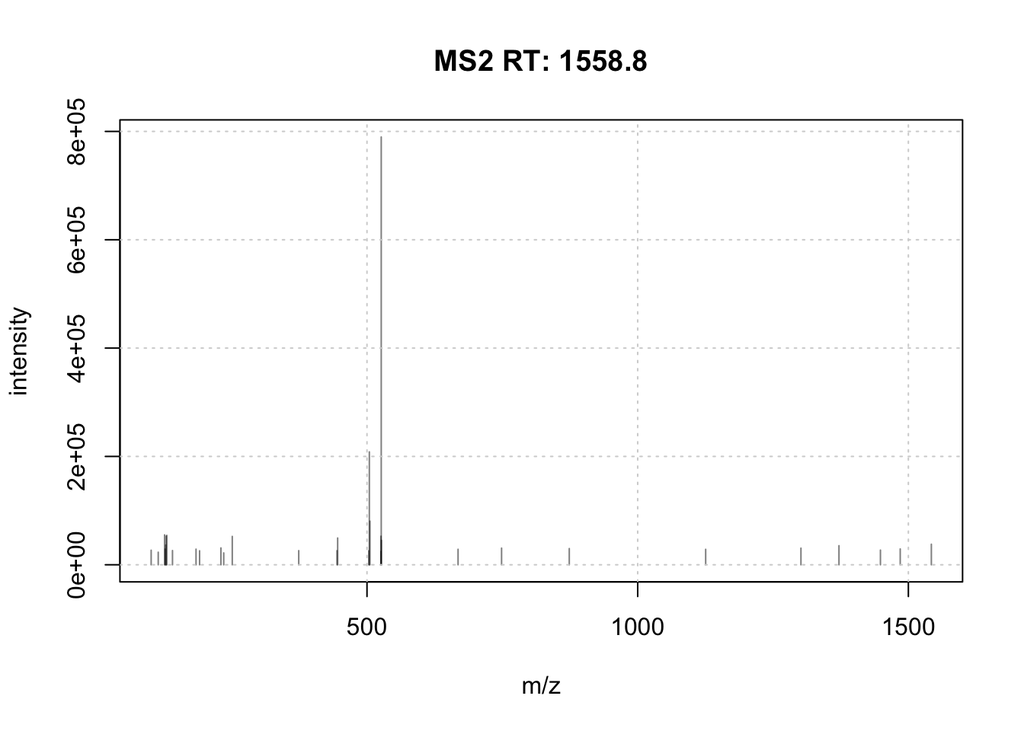

```r
plotSpectra(sp2[1230]); grid()
```

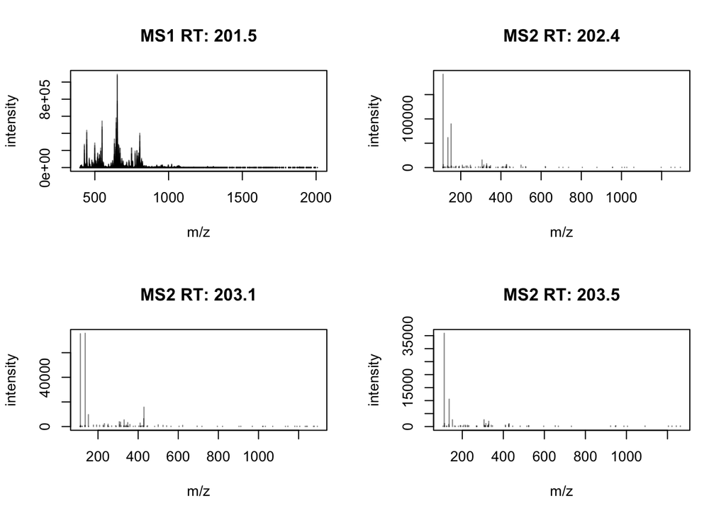

```r
plotSpectra(sp[226:229]) # MS1 vs. MS2 spectra
```

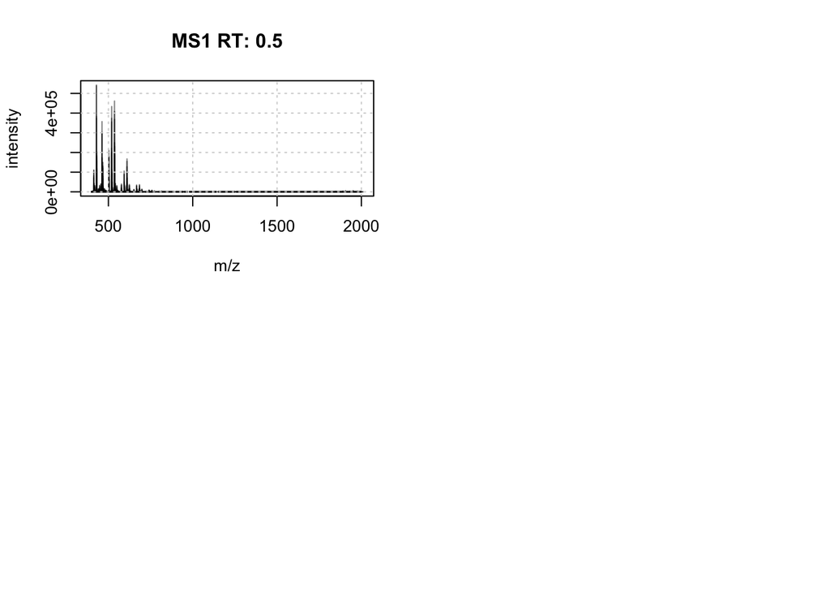

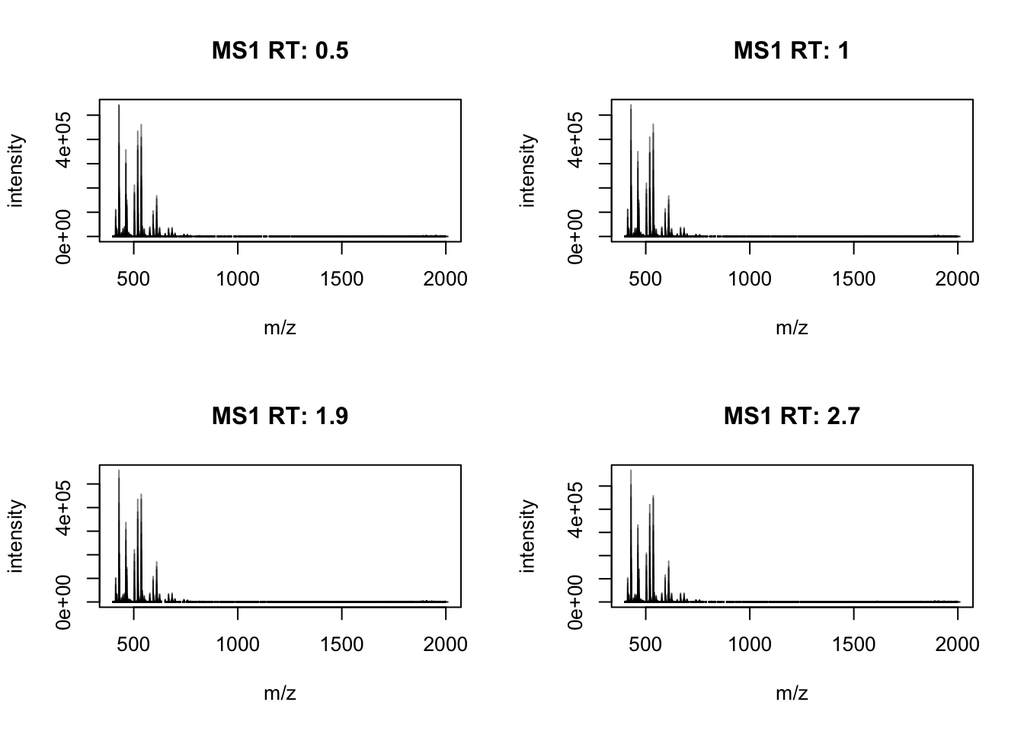

```r
plotSpectra(sp[1]); grid()
plotSpectra(sp[1:4])
```

## Visulaize the spectra

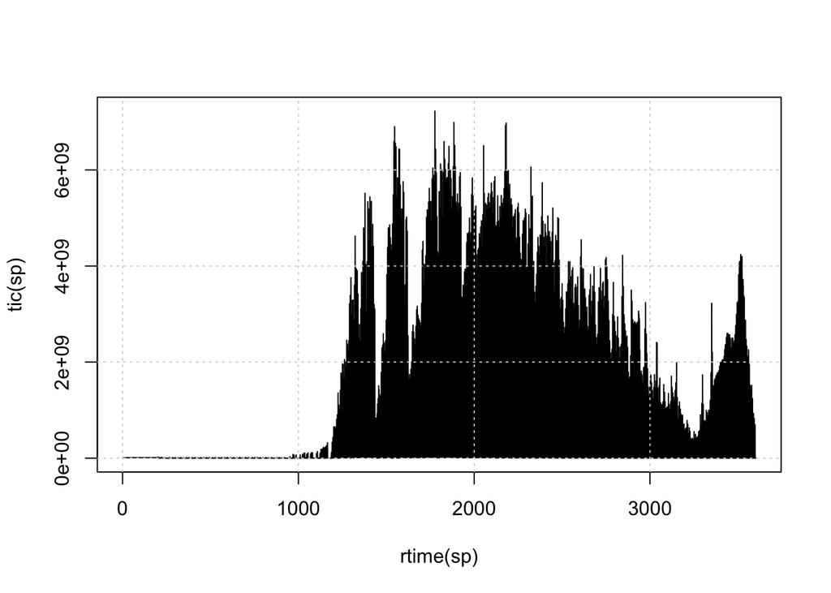

```r
## The chromatogram can be created by extracting the totIonCurrent (TIC) and rtime variables for all MS1 spectra.
## Lets annotate the spectrum of interest.

plot(rtime(sp), tic(sp), type = "l"); grid()
```

```r
#plot(sp$rtime, sp$totIonCurrent, type = "l"); grid()

(sp1 <- filterMsLevel(sp, 1L))
```

```
## MSn data (Spectra) with 1431 spectra in a MsBackendMzR backend:
##        msLevel     rtime scanIndex
##      <integer> <numeric> <integer>
## 1            1    0.4584         1
## 2            1    0.9725         2
## 3            1    1.8524         3
## 4            1    2.7424         4
## 5            1    3.6124         5
## ...        ...       ...       ...
## 1427         1   3578.58      7480
## 1428         1   3583.25      7491
## 1429         1   3588.62      7502
## 1430         1   3593.25      7513
## 1431         1   3597.97      7524
##  ... 34 more variables/columns.
##
## file(s):
## 100d1647358d7_TMT_Erwinia_1uLSike_Top10HCD_isol2_45stepped_60min_01-20141210.mzML
## Processing:
##  Filter: select MS level(s) 1 [Fri May  1 11:48:45 2026]
```

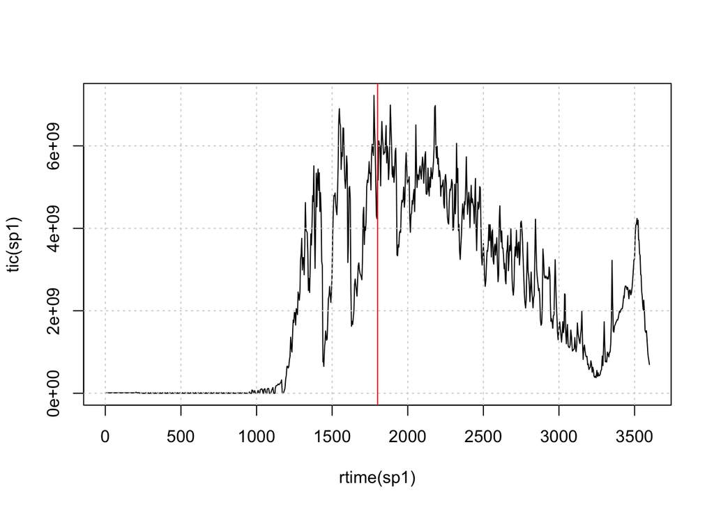

```r
plot(rtime(sp1), tic(sp1), type = "l"); grid(); abline(v = rtime(sp)[2807], col = "red")
```

```r
MsCoreUtils::formatRt(rtime(sp)[2800:2820]) # Convert to Min:Sec format
```

```
##  [1] "29:58" "29:59" "29:59" "29:59" "29:60" "29:60" "30:00" "30:01" "30:01"
## [10] "30:02" "30:02" "30:02" "30:03" "30:03" "30:03" "30:04" "30:04" "30:04"
## [19] "30:05" "30:05" "30:06"
```

```r
sp[2807]
```

```
## MSn data (Spectra) with 1 spectra in a MsBackendMzR backend:
##     msLevel     rtime scanIndex
##   <integer> <numeric> <integer>
## 1         1   1800.68      2807
##  ... 34 more variables/columns.
##
## file(s):
## 100d1647358d7_TMT_Erwinia_1uLSike_Top10HCD_isol2_45stepped_60min_01-20141210.mzML
```

## ggplot visualization

```r
library(tidyverse)
```

```
## ✖ lubridate::second<-()    masks S4Vectors::second<-()
```

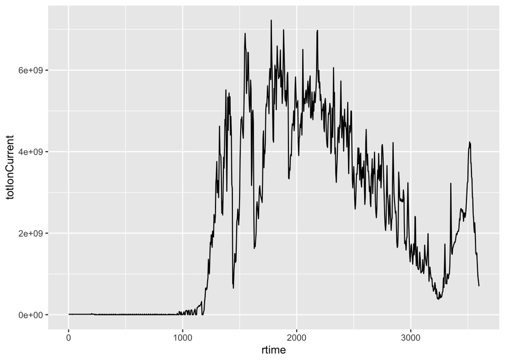

```r
spectraData(sp) |>
    as_tibble() |>
    filter(msLevel == 1) |>
    ggplot(aes(x = rtime,
               y = totIonCurrent)) +
    geom_line()
```

### Quiz 2 (GA_5)

Visit `gosocrative.com` and enter room name `FIN2026`

```r
# The filterPrecursorScan() function can be used to retain a set parent (MS1) and children scans (MS2),
# as defined by an acquisition number, Use it to extract the MS1 scan of interest and all its MS2 children.

(sp2 <- filterPrecursorScan(sp, 2807)) # a family of scans
```

```
## MSn data (Spectra) with 11 spectra in a MsBackendMzR backend:
##      msLevel     rtime scanIndex
##    <integer> <numeric> <integer>
## 1          1   1800.68      2807
## 2          2   1801.26      2808
## 3          2   1801.92      2809
## 4          2   1802.20      2810
## 5          2   1802.48      2811
## 6          2   1802.77      2812
## 7          2   1803.05      2813
## 8          2   1803.34      2814
## 9          2   1803.64      2815
## 10         2   1803.93      2816
## 11         2   1804.21      2817
##  ... 34 more variables/columns.
##
## file(s):
## 100d1647358d7_TMT_Erwinia_1uLSike_Top10HCD_isol2_45stepped_60min_01-20141210.mzML
## Processing:
##  Filter: select parent/children scans for 2807 [Fri May  1 11:48:45 2026]
```

```r
precScanNum(sp2)
```

```
##  [1]   NA 2807 2807 2807 2807 2807 2807 2807 2807 2807 2807
```

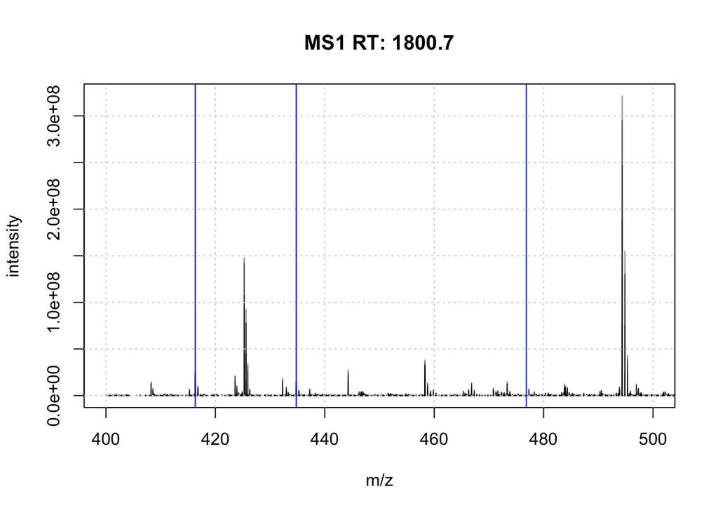

```r
# Plot the MS1 spectrum of interest and highlight all the peaks that will be selected for MS2 analysis
# plotSpectra()

plotSpectra(sp2[1], xlim = c(400, 500)); grid(); abline(v = precursorMz(sp2)[-1], col = "blue")
```

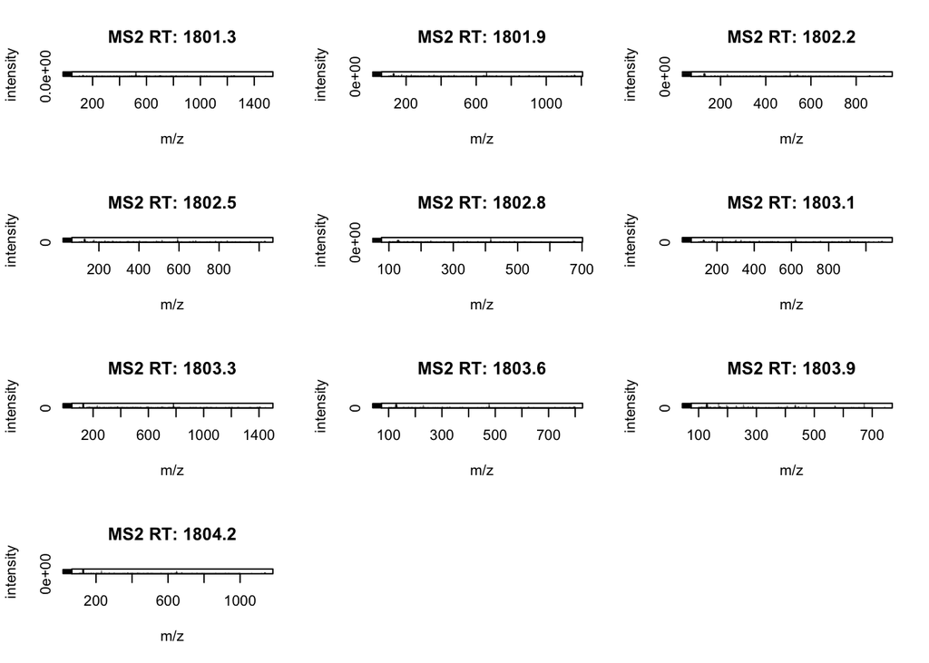

```r
# Use plotSpectra() function to plot all 10 MS2 spectra in one call.
plotSpectra(sp2[-1])
# plotSpectra(sp2[2:11])
# plotSpectra(filterMsLevel(sp2, 2L))[1]
```

## Focus of mz range

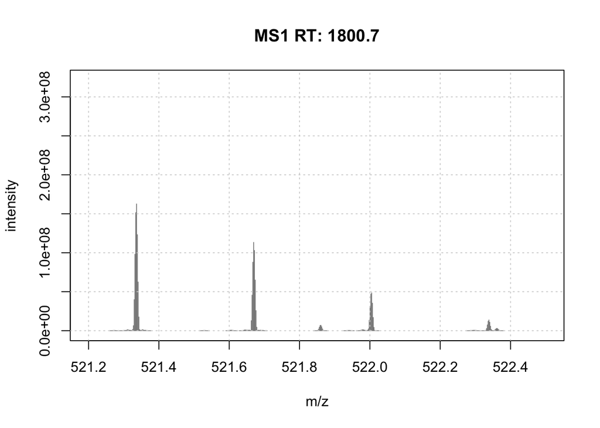

```r
plotSpectra(sp[2807], xlim = c(521.2, 522.5)); grid()
```

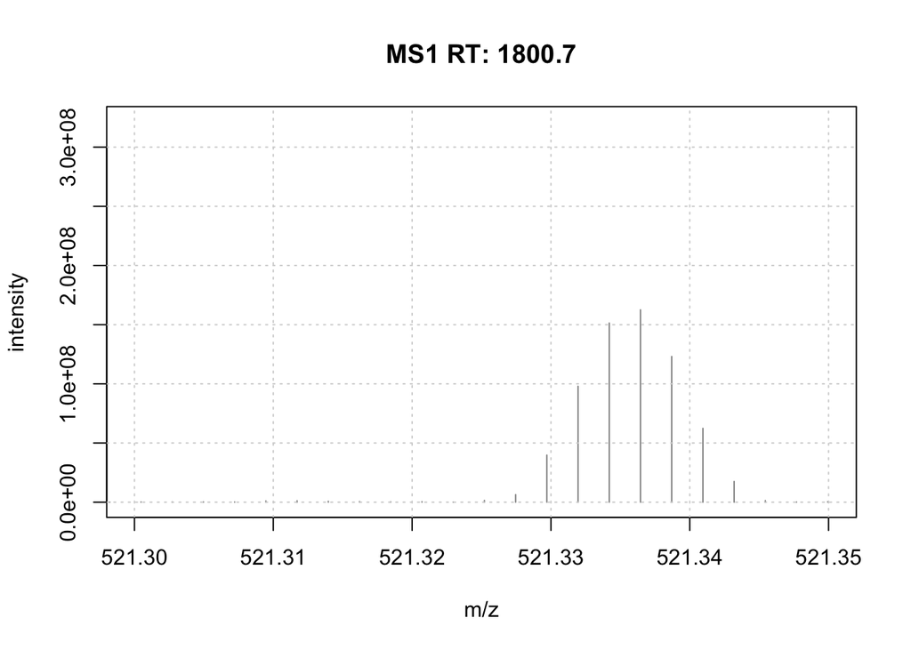

```r
plotSpectra(sp[2807], xlim = c(521.3, 521.35)); grid()
```

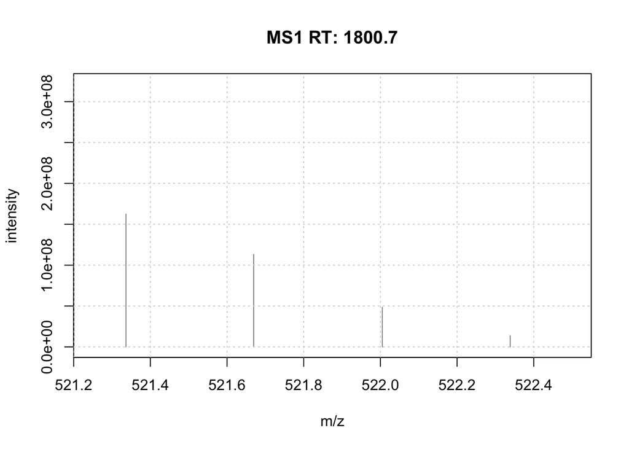

```r
## Processing of MS raw data as `profile mode of spectrum`
## that's because there is some uncertainty in all in what is measured by the MS (imperfection of device)
## `centroid mode of spectrum`
Spectra::pickPeaks(sp[2807]) |>
    filterIntensity(1e7) |>
    plotSpectra(xlim = c(521.25, 522.5)); grid()
```

```r
## Normally MS1 is produced as profile mode and MS2 as centroid mode when we convert them to mzML
table(msLevel(sp), centroided(sp))
```

```
##
##     FALSE TRUE
##   1  1431    0
##   2     0 6103
```

```r
# Spectra::filter... family functions
```

## More Visulization

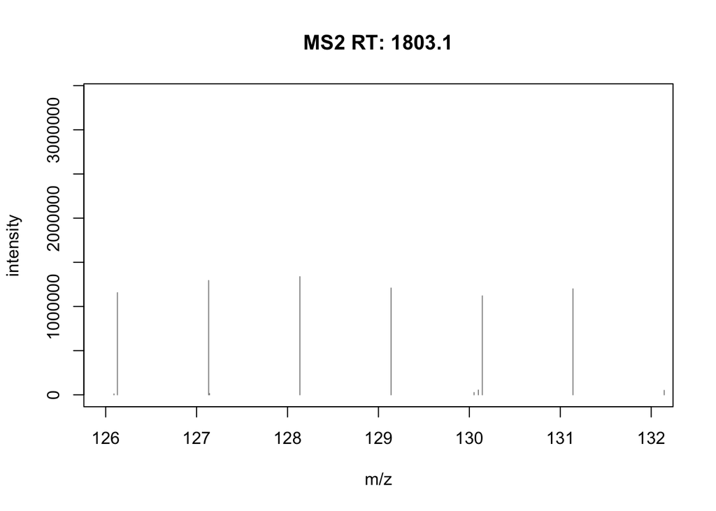

```r
plotSpectra(sp2[7],
            xlim = c(126, 132))
```

```r
(z <- peaksData(sp2[7])[[1L]])
```

```
##               mz   intensity
##   [1,]  101.0721   25041.314
##   [2,]  102.0560  165852.422
##   [3,]  110.0724  130727.594
##   [4,]  111.0757   17039.324
##   [5,]  112.0882   84343.227
##   [6,]  113.0713   16618.086
##   [7,]  115.0877   94740.008
##   [8,]  116.0715  105272.602
##   [9,]  120.0820  235803.031
##  [10,]  126.0910    9315.648
##  [11,]  126.1289 1155635.625
##  [12,]  127.1323 1293352.500
##  [13,]  127.1417   13949.328
##  [14,]  128.1357 1337015.750
```

[output cut: 212 more lines]

```r
z[,"intensity"] |> summary()
```

```
##    Min. 1st Qu.  Median    Mean 3rd Qu.    Max.
##    9316   20284   36668  155674  100748 3385160
```

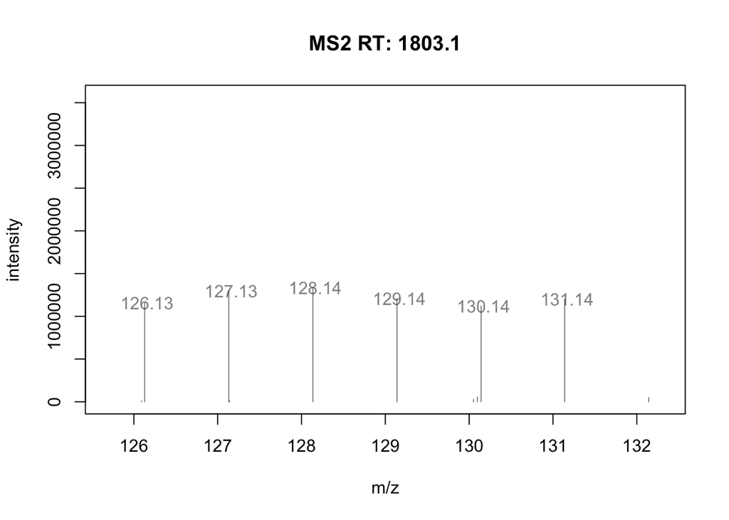

```r
mzLabel <- function(z) {
    ## z is an instance of class Spectra
    z <- peaksData(z)[[1L]]
    lab <- format(z[, "mz"], digits = 5) # to decrease number of digit
    lab[z[, "intensity"] < 1e6] <- "" # to exclude low intensity peaks
    lab
}

plotSpectra(sp2[7],
            labels = mzLabel, # this is a function to label high intensity peaks
            xlim = c(126, 132))
```

```r
sp2 <- filterMsLevel(sp, 2L)

anyDuplicated(precursorMz(sp2))
```

```
## [1] 37
```

```r
(i <- which(precursorMz(sp2) == precursorMz(sp2)[37]))
```

```
## [1] 31 37
```

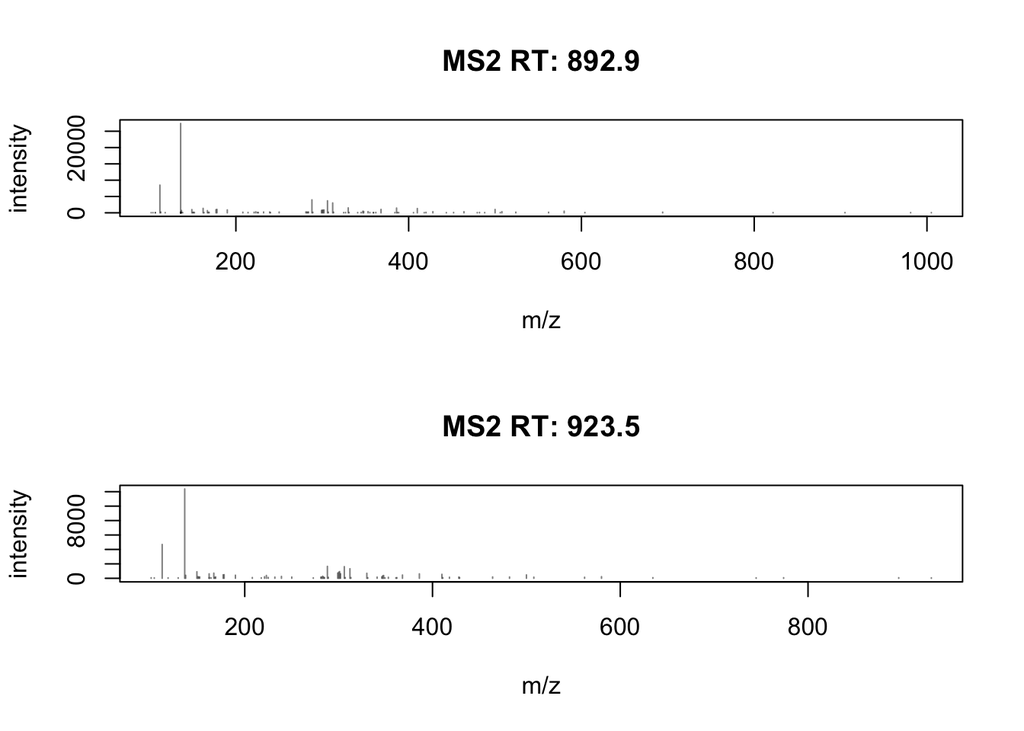

```r
plotSpectra(sp2[i])
```

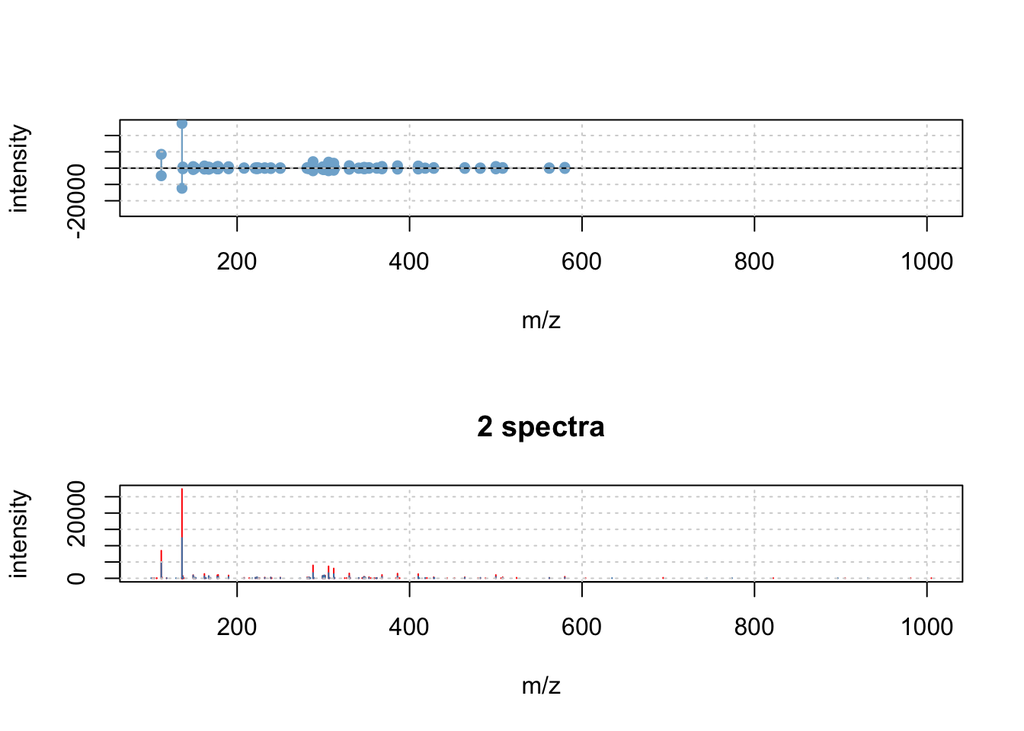

```r
plotSpectraMirror(sp2[31], sp2[37]); grid()

plotSpectraOverlay(sp2[i], col = c("red", "steelblue")); grid()
```

```r
# BiocManager::install("RforMassSpectrometry/SpectraVis")
library(SpectraVis)

plotlySpectra(sp2[37])

browseSpectra(sp)
```

## Fragment Ions

### 1. Backbone Fragment Ions

When a peptide is fragmented in MS/MS, it breaks along the backbone, producing ions depending on where the charge is retained.

#### Main Ion Types

| Ion type | Origin | Direction |
| --- | --- | --- |
| a-ions | b-ion − CO | N-terminus |
| b-ions | N-terminal fragments | N → C |
| c-ions | N-terminal (ETD-type) | N → C |
| x-ions | C-terminal (rare) | C → N |
| y-ions | C-terminal fragments | C → N |
| z-ions | C-terminal (ETD-type) | C → N |

#### Intuition

- **b / y ions** → most common (CID/HCD)
- **c / z ions** → ETD/ECD fragmentation
- **a ions** → less abundant (loss of CO from b)

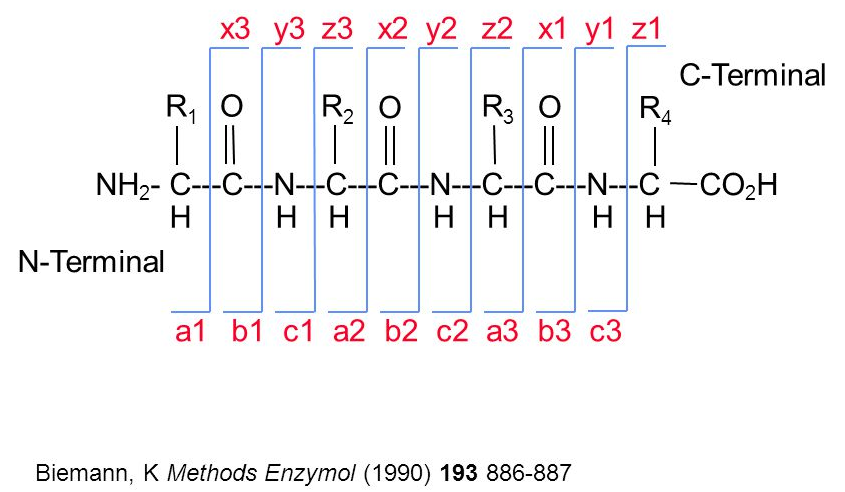

### 2. Internal Fragment Ions

- Formed by multiple backbone cleavages
- Do not include peptide termini
- Less common and harder to interpret

for further study, see: How to Deal With Internal Fragment Ions?

### 3. Neutral Loss Ions

Fragments may lose small neutral molecules:

- H₂O loss (−18 Da) → Ser, Thr, Glu, Asp
- NH₃ loss (−17 Da) → Lys, Arg, Asn, Gln

### 4. Immonium Ions

Small diagnostic ions indicating specific amino acids.

Examples:

- Tyrosine → m/z 136
- Phenylalanine → m/z 120

### 5. Reporter Ions

- Used in labeling methods (e.g., TMT, iTRAQ)
- Appear at low m/z
- Indicate sample origin and abundance

### Fragmentation Methods in proteomics

#### CID (Collision-Induced Dissociation)

- Peptides collide with gas molecules
- Slow heating fragmentation

#### HCD (Higher-energy C-trap Dissociation)

- Higher-energy version of CID

**Advantage:** Strong low-mass ions (useful for reporter ions)

#### ETD (Electron Transfer Dissociation)

- Electron transfer to peptide

**Advantage:** preserves post-translational modifications

#### ECD (Electron Capture Dissociation)

- Similar to ETD (used in FTICR instruments)

#### Hybrid Methods (EThcD)

- Combination of ETD and HCD

| Method | Ion types | Strength |
| --- | --- | --- |
| CID | b, y | Standard sequencing |
| HCD | b, y (+ reporter ions) | Quantification |
| ETD | c, z | PTM preservation |
| ECD | c, z | High-resolution analysis |
| EThcD | b, y, c, z | Best coverage |

```r
#library(PSMatch)
calculateFragments("TAFDEAIAELDTLNEESYK")
calculateFragments("TAFDEAIAELDTLNEESYK", type=c("a", "b", "c", "x", "y", "z"),
                   z=1:2)
```

[output not shown]

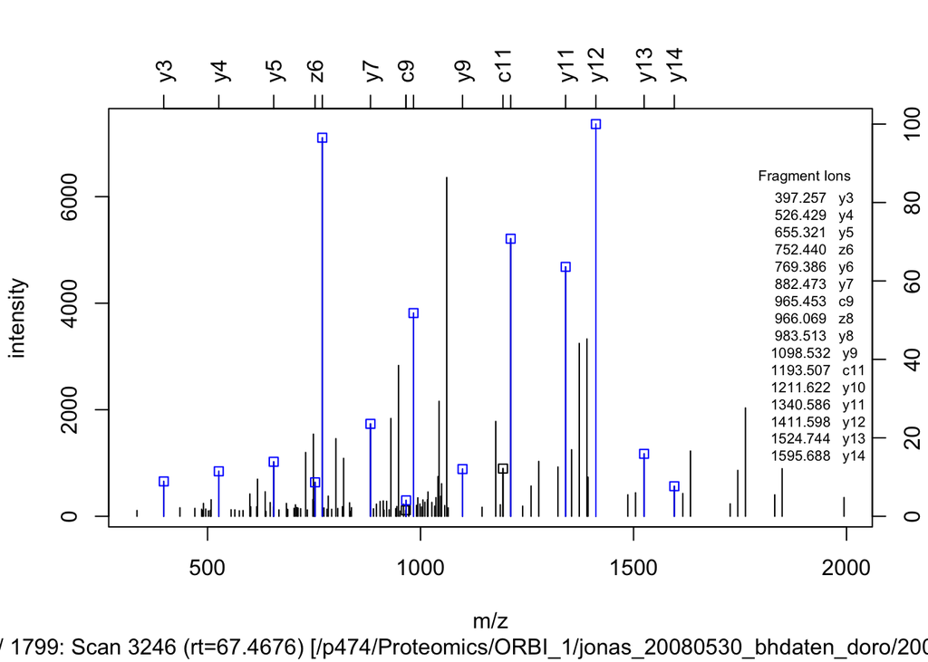

```r
library("protViz")
data(msms)

fi <- fragmentIon("TAFDEAIAELDTLNEESYK")
fi.cyz <- as.data.frame(cbind(c=fi[[1]]$c, y=fi[[1]]$y, z=fi[[1]]$z))

p <- peakplot("TAFDEAIAELDTLNEESYK",
              spec = msms[[1]],
              fi = fi.cyz,
              itol = 0.6,
              ion.axes = FALSE)
```

### Quiz 3 (GA_6)

Visit `gosocrative.com` and enter room name `FIN2026`

## Working with msdata and an examplary mzID file

```r
library(PSMatch)
library(msdata)
ident() # Restart R session if it is empty object
```

```
## [1] "TMT_Erwinia_1uLSike_Top10HCD_isol2_45stepped_60min_01-20141210.mzid"
```

```r
idf <- ident(full.names = TRUE)
basename(idf)
```

```
## [1] "TMT_Erwinia_1uLSike_Top10HCD_isol2_45stepped_60min_01-20141210.mzid"
```

```r
# PSM when we can match a spectrum to a peptide using a Search engine software (third-party software) such as Mascot, PD, Sage, MaxQuant, SAGE (https://sage-docs.vercel.app/docs), etc.
# The standard format to read the output of search engine is mzIdentML(mzid) file.
id <- PSM(idf)
# saveRDS(id, file = "psm_object_msdata_ident.rds")
# id <- readRDS("psm_object_msdata_ident.rds")
dim(id)
```

```
## [1] 5802   35
```

```r
names(id)
```

```
##  [1] "sequence"                 "spectrumID"
##  [3] "chargeState"              "rank"
##  [5] "passThreshold"            "experimentalMassToCharge"
##  [7] "calculatedMassToCharge"   "peptideRef"
##  [9] "modNum"                   "isDecoy"
## [11] "post"                     "pre"
## [13] "start"                    "end"
## [15] "DatabaseAccess"           "DBseqLength"
## [17] "DatabaseSeq"              "DatabaseDescription"
## [19] "scan.number.s."           "acquisitionNum"
## [21] "spectrumFile"             "idFile"
## [23] "MS.GF.RawScore"           "MS.GF.DeNovoScore"
## [25] "MS.GF.SpecEValue"         "MS.GF.EValue"
## [27] "MS.GF.QValue"             "MS.GF.PepQValue"
## [29] "modPeptideRef"            "modName"
## [31] "modMass"                  "modLocation"
## [33] "subOriginalResidue"       "subReplacementResidue"
## [35] "subLocation"
```

```r
head(id$spectrumID)
```

```
## [1] "controllerType=0 controllerNumber=1 scan=2949"
## [2] "controllerType=0 controllerNumber=1 scan=6534"
## [3] "controllerType=0 controllerNumber=1 scan=5674"
## [4] "controllerType=0 controllerNumber=1 scan=4782"
## [5] "controllerType=0 controllerNumber=1 scan=5839"
## [6] "controllerType=0 controllerNumber=1 scan=6118"
```

```r
head(id$spectrumFile)
```

```
## [1] "TMT_Erwinia_1uLSike_Top10HCD_isol2_45stepped_60min_01-20141210.mzML"
## [2] "TMT_Erwinia_1uLSike_Top10HCD_isol2_45stepped_60min_01-20141210.mzML"
## [3] "TMT_Erwinia_1uLSike_Top10HCD_isol2_45stepped_60min_01-20141210.mzML"
## [4] "TMT_Erwinia_1uLSike_Top10HCD_isol2_45stepped_60min_01-20141210.mzML"
## [5] "TMT_Erwinia_1uLSike_Top10HCD_isol2_45stepped_60min_01-20141210.mzML"
## [6] "TMT_Erwinia_1uLSike_Top10HCD_isol2_45stepped_60min_01-20141210.mzML"
```

```r
head(id$sequence)
```

```
## [1] "RQCRTDFLNYLR"              "ESVALADQVTCVDWRNRKATKK"
## [3] "KELLCLAMQIIR"              "QRMARTSDKQQSIRFLERLCGR"
## [5] "KDEGSTEPLKVVRDMTDAICMLLR"  "DGGPAIYGHERVGRNAKKFKCLKFR"
```

```r
head(id$DatabaseAccess)
```

```
## [1] "ECA2006"     "ECA1676"     "XXX_ECA2855" "ECA3009"     "XXX_ECA0048"
## [6] "ECA1420"
```

```r
## Ex1- Verify that this table contains 5802 matches for 5343 scans and 4938 peptides sequences and 3148 proteins.
names(id)
```

```
##  [1] "sequence"                 "spectrumID"
##  [3] "chargeState"              "rank"
##  [5] "passThreshold"            "experimentalMassToCharge"
##  [7] "calculatedMassToCharge"   "peptideRef"
##  [9] "modNum"                   "isDecoy"
## [11] "post"                     "pre"
## [13] "start"                    "end"
## [15] "DatabaseAccess"           "DBseqLength"
## [17] "DatabaseSeq"              "DatabaseDescription"
## [19] "scan.number.s."           "acquisitionNum"
## [21] "spectrumFile"             "idFile"
## [23] "MS.GF.RawScore"           "MS.GF.DeNovoScore"
## [25] "MS.GF.SpecEValue"         "MS.GF.EValue"
## [27] "MS.GF.QValue"             "MS.GF.PepQValue"
## [29] "modPeptideRef"            "modName"
## [31] "modMass"                  "modLocation"
## [33] "subOriginalResidue"       "subReplacementResidue"
## [35] "subLocation"
```

```r
length(unique(id$spectrumID))
```

```
## [1] 5343
```

```r
length(unique(id$sequence))
```

```
## [1] 4938
```

```r
length(unique(id$DatabaseAccess))
```

```
## [1] 3148
```

```r
library(tibble)

as.data.frame(id) |>
    as_tibble() |>
  DT::datatable()
```

|  | sequence | spectrumID | chargeState | rank | passThreshold | experimentalMassToCharge | calculatedMassToCharge | peptideRef | modNum | isDecoy | post | pre | start | end | DatabaseAccess | DBseqLength | DatabaseSeq | DatabaseDescription | scan.number.s. | acquisitionNum | spectrumFile | idFile | MS.GF.RawScore | MS.GF.DeNovoScore | MS.GF.SpecEValue | MS.GF.EValue | MS.GF.QValue | MS.GF.PepQValue | modPeptideRef | … |
| --- | --- | --- | --- | --- | --- | --- | --- | --- | --- | --- | --- | --- | --- | --- | --- | --- | --- | --- | --- | --- | --- | --- | --- | --- | --- | --- | --- | --- | --- | --- |
| 1 | RQCRTDFLNYLR | controllerType=0 controllerNumber=1 scan=2949 | 3 | 1 | True | 548.2855834960938 | 547.9474487304688 | Pep77 | 1 | False | V | R | 574 | 585 | ECA2006 | 1295 |  | ECA2006 ATP-dependent helicase | 2949 | 2949 | TMT_Erwinia_1uLSike_Top10HCD_isol2_45stepped_60min_01-20141210.mzML | TMT_Erwinia_1uLSike_Top10HCD_isol2_45stepped_60min_01-20141210.mzid | 10 | 101 | 4.6171213e-08 | 0.13219807 | 0.5254237 | 0.54901963 | Pep77 | … |
| 2 | ESVALADQVTCVDWRNRKATKK | controllerType=0 controllerNumber=1 scan=6534 | 2 | 1 | True | 1288.15283203125 | 1288.174072265625 | Pep108 | 1 | False | G | R | 69 | 90 | ECA1676 | 110 |  | ECA1676 putative growth inhibitory protein | 6534 | 6534 | TMT_Erwinia_1uLSike_Top10HCD_isol2_45stepped_60min_01-20141210.mzML | TMT_Erwinia_1uLSike_Top10HCD_isol2_45stepped_60min_01-20141210.mzid | 12 | 121 | 7.255875e-08 | 0.2087481 | 0.6103896 | 0.6231884 | Pep108 | … |
| 3 | KELLCLAMQIIR | controllerType=0 controllerNumber=1 scan=5674 | 2 | 1 | True | 744.4109497070312 | 744.4254760742188 | Pep136 | 1 | True | Q | R | 131 | 142 | XXX_ECA2855 | 157 |  |  | 5674 | 5674 | TMT_Erwinia_1uLSike_Top10HCD_isol2_45stepped_60min_01-20141210.mzML | TMT_Erwinia_1uLSike_Top10HCD_isol2_45stepped_60min_01-20141210.mzid | 8 | 74 | 9.3410186e-08 | 0.26745334 | 0.625 | 0.6363636 | Pep136 | … |
| 4 | QRMARTSDKQQSIRFLERLCGR | controllerType=0 controllerNumber=1 scan=4782 | 3 | 1 | True | 913.1642456054688 | 912.8134155273438 | Pep163 | 1 | False | D | R | 182 | 203 | ECA3009 | 437 |  | ECA3009 putative coproporphyrinogen oxidase | 4782 | 4782 | TMT_Erwinia_1uLSike_Top10HCD_isol2_45stepped_60min_01-20141210.mzML | TMT_Erwinia_1uLSike_Top10HCD_isol2_45stepped_60min_01-20141210.mzid | -5 | 160 | 1.2707308e-07 | 0.3655833 | 0.7169811 | 0.7244898 | Pep163 | … |
| 5 | KDEGSTEPLKVVRDMTDAICMLLR | controllerType=0 controllerNumber=1 scan=5839 | 3 | 1 | True | 926.8101806640625 | 926.4713134765625 | Pep169 | 1 | True | R | R | 135 | 158 | XXX_ECA0048 | 501 |  |  | 5839 | 5839 | TMT_Erwinia_1uLSike_Top10HCD_isol2_45stepped_60min_01-20141210.mzML | TMT_Erwinia_1uLSike_Top10HCD_isol2_45stepped_60min_01-20141210.mzid | 8 | 241 | 1.3182397e-07 | 0.37946057 | 0.73636365 | 0.74509805 | Pep169 | … |
| 6 | DGGPAIYGHERVGRNAKKFKCLKFR | controllerType=0 controllerNumber=1 scan=6118 | 3 | 1 | True | 969.1942749023438 | 968.8556518554688 | Pep206 | 1 | False | S | K | 310 | 334 | ECA1420 | 477 |  | ECA1420 undecaprenyl-phosphate galactosephosphotransferase | 6118 | 6118 | TMT_Erwinia_1uLSike_Top10HCD_isol2_45stepped_60min_01-20141210.mzML | TMT_Erwinia_1uLSike_Top10HCD_isol2_45stepped_60min_01-20141210.mzid | 7 | 214 | 1.7220331e-07 | 0.49581707 | 0.837037 | 0.856 | Pep206 | … |
| 7 | QRMARTSDKQQSIRFLERLCGR | controllerType=0 controllerNumber=1 scan=4757 | 2 | 1 | True | 1369.238037109375 | 1368.716552734375 | Pep163 | 1 | False | D | R | 182 | 203 | ECA3009 | 437 |  | ECA3009 putative coproporphyrinogen oxidase | 4757 | 4757 | TMT_Erwinia_1uLSike_Top10HCD_isol2_45stepped_60min_01-20141210.mzML | TMT_Erwinia_1uLSike_Top10HCD_isol2_45stepped_60min_01-20141210.mzid | 21 | 196 | 1.7684022e-07 | 0.508761 | 0.837037 | 0.7244898 | Pep163 | … |
| 8 | CIDRARHVEVQIFGDGKGRVVALGERDCSLQRR | controllerType=0 controllerNumber=1 scan=6518 | 3 | 1 | True | 1285.320068359375 | 1285.002563476562 | Pep216 | 2 | False | N | R | 201 | 233 | ECA2142 | 1204 |  | ECA2142 urea amidolyase | 6518 | 6518 | TMT_Erwinia_1uLSike_Top10HCD_isol2_45stepped_60min_01-20141210.mzML | TMT_Erwinia_1uLSike_Top10HCD_isol2_45stepped_60min_01-20141210.mzid | -31 | 165 | 1.8045459e-07 | 0.5203928 | 0.837037 | 0.856 | Pep216 | … |
| 9 | CIDRARHVEVQIFGDGKGRVVALGERDCSLQRR | controllerType=0 controllerNumber=1 scan=6518 | 3 | 1 | True | 1285.320068359375 | 1285.002563476562 | Pep216 | 2 | False | N | R | 201 | 233 | ECA2142 | 1204 |  | ECA2142 urea amidolyase | 6518 | 6518 | TMT_Erwinia_1uLSike_Top10HCD_isol2_45stepped_60min_01-20141210.mzML | TMT_Erwinia_1uLSike_Top10HCD_isol2_45stepped_60min_01-20141210.mzid | -31 | 165 | 1.8045459e-07 | 0.5203928 | 0.837037 | 0.856 | Pep216 | … |
| 10 | VGRCRPIINYLASPGGTSER | controllerType=0 controllerNumber=1 scan=6356 | 2 | 1 | True | 1102.0556640625 | 1102.07373046875 | Pep223 | 1 | False | L | R | 121 | 140 | ECA0331 | 210 |  | ECA0331 ADP-ribose pyrophosphatase | 6356 | 6356 | TMT_Erwinia_1uLSike_Top10HCD_isol2_45stepped_60min_01-20141210.mzML | TMT_Erwinia_1uLSike_Top10HCD_isol2_45stepped_60min_01-20141210.mzid | -3 | 59 | 1.8766944e-07 | 0.53957856 | 0.837037 | 0.856 | Pep223 | … |

[output cut: 5792 more lines]

## Decoy set understanding

```r
## Target: protein.fasta -> peptide
## Decoy:  reverse protein.fasta -> peptide
## One of the benefit of the Reverse peptide set as a decoy set is that the probability of pair of a.a. are same as the target set.

table(id$isDecoy)
```

```
##
## FALSE  TRUE
##  2906  2896
```

```r
head(id$DatabaseAccess)
```

```
## [1] "ECA2006"     "ECA1676"     "XXX_ECA2855" "ECA3009"     "XXX_ECA0048"
## [6] "ECA1420"
```

```r
head(id$isDecoy)
```

```
## [1] FALSE FALSE  TRUE FALSE  TRUE FALSE
```

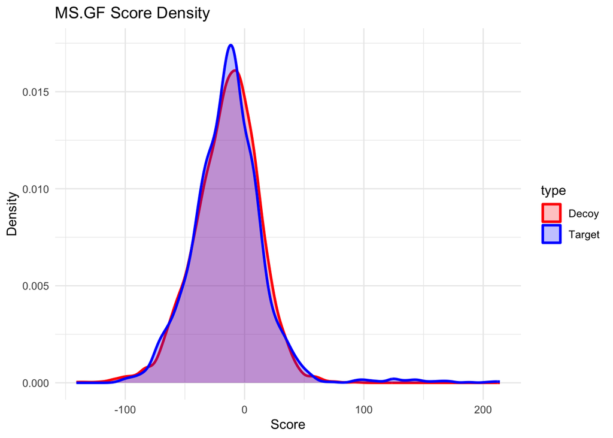

```r
library(ggplot2)

df <- data.frame(
  score = id$MS.GF.RawScore,
  type = ifelse(id$isDecoy, "Decoy", "Target")
)

ggplot(df, aes(score, color = type, fill = type)) +
  geom_density(alpha = 0.25, linewidth = 1) +
  scale_color_manual(values = c(Decoy = "red", Target = "blue")) +
  scale_fill_manual(values = c(Decoy = "red", Target = "blue")) +
  labs(title = "MS.GF Score Density", x = "Score", y = "Density") +
  theme_minimal()
```

In summary, two key assumptions must be satisfied:

*Assumption 1*: Decoy PSMs provide an accurate model of incorrect target matches, meaning the score distributions of decoy hits and false target hits are equivalent.

*Assumption 2*: When target and decoy databases are of equal size, any incorrect (random) match is equally likely to be assigned to a target or a decoy sequence.

## Enzyme digestion

```r
rTinyPro <-"LAAGKVEDSD"

library(cleaver)
cleave(rTinyPro, "trypsin")
```

```
## $LAAGKVEDSD
## [1] "LAAGK" "VEDSD"
```

```r
cleavageRanges(rTinyPro, "trypsin")
```

```
## $LAAGKVEDSD
##      start end
## [1,]     1   5
## [2,]     6  10
```

```r
cleavageSites(rTinyPro, "trypsin")
```

```
## $LAAGKVEDSD
## [1] 5
```

```r
cleave(rTinyPro, "trypsin", missedCleavages = 1)
```

```
## $LAAGKVEDSD
## [1] "LAAGKVEDSD"
```

```r
cleavageRanges(rTinyPro, "trypsin", missedCleavages = 1)
```

```
## $LAAGKVEDSD
##      start end
## [1,]     1  10
```